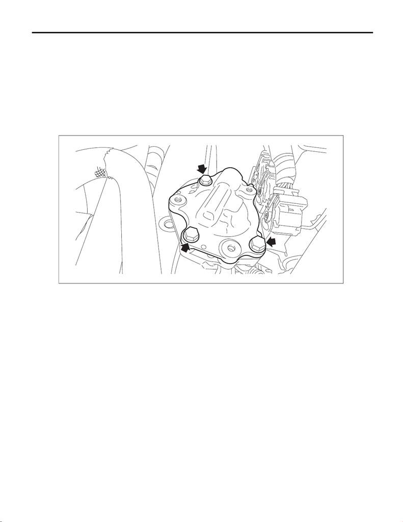

LU(w/o STI)-43

Scavenge Pump

LUBRICATION

10.Scavenge Pump

A: REMOVAL

CAUTION:

If engine oil is spilt onto the exhaust pipe, wipe it off with cloth to avoid emission of smoke or causing

a fire.

1) Remove the oil pipe assembly. <Ref. to LU(w/o STI)-45, OIL PIPE ASSY, REMOVAL, Oil Pipe.>

2) Remove the bolts which secure the scavenge pump to the intake rear camshaft cap RH and the cam car-

rier RH. Using a crowbar, remove the scavenge pump.

CAUTION:

Be careful not to damage the mating surfaces of the cylinder head and scavenge pump.

LU-03198

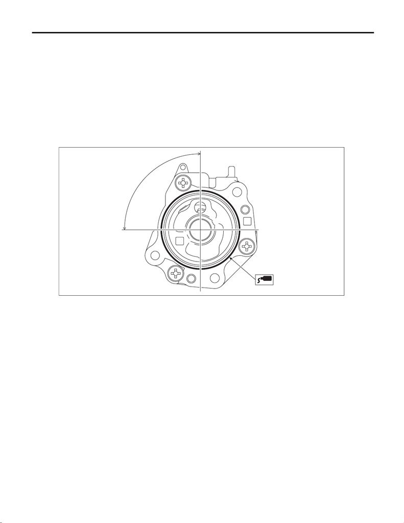

LU(w/o STI)-44

Scavenge Pump

LUBRICATION

B: INSTALLATION

Install in the reverse order of removal.

CAUTION:

Do not start applying the gasket in the (A) region in the figure below.

NOTE:

• Use a new gasket.

• Install within 5 min. after applying liquid gasket.

Liquid gasket:

THREE BOND 1217G (Part No. K0877Y0100) or equivalent

Liquid gasket applying diameter:

3

±

1 mm (0.1181

±

0.0394 in)

Tightening torque:

6.4 N·m (0.7 kgf-m, 4.7 ft-lb)

C: INSPECTION

1) Check that the scavenge hose has no deformation, cracks or other damages.

2) Check that the scavenge pump has no crack, damage, or looseness.

LU-03095

(A)